# Name: Mit Lalitbhai Patel

# Step 1.2

```python
inspection_df['Month'] = pd.DatetimeIndex(inspection_df['Inspection Date']).month
inspection_df['Year'] = pd.DatetimeIndex(inspection_df['Inspection Date']).year
inspection_df['month_year'] = pd.to_datetime(inspection_df['Inspection Date']).dt.to_period('M')
inspection_df.head()
```

|  | Establishment ID | Name | Address 1 | Address 2 | City | Zip | Inspection Date | Inspection Results | Food from Approved Source (C) | Food Protected from Contamination (C) | ... | Owner | Category | Type | Latitude | Longitude | Location | Is_Restaurant | Month | Year | month_year |
| --- | --- | --- | --- | --- | --- | --- | --- | --- | --- | --- | --- | --- | --- | --- | --- | --- | --- | --- | --- | --- | --- |
| 0 | 18628 | SUBWAY #22916 | 12193 DARNESTOWN RD. | NaN | GAITHERSBURG | 20878 | 12/19/2018 | No Critical Violations Noted | In Compliance | In Compliance | ... | P. N. ENTERPRISES, LLC | Restaurant | Food | 39.1179 | -77.2524 | (39.1179, -77.2524) | 1 | 12 | 2018 | 2018-12 |
| 1 | 1059 | GIANT FOOD #0192 | 18250 FLOWER HILL WAY | NaN | GAITHERSBURG | 20879 | 12/19/2018 | Critical Violations Corrected | In Compliance | In Compliance | ... | GIANT OF MARYLAND, LLC | Market | Food | 39.1551 | -77.1659 | (39.1551, -77.1659) | 0 | 12 | 2018 | 2018-12 |
| 2 | 20933 | PIZZA BOLIS | 7831 EASTERN AVE. | NaN | SILVER SPRING | 20910 | 12/19/2018 | No Critical Violations Noted | In Compliance | In Compliance | ... | K.M.MG INC | Restaurant | Food | 38.9853 | -77.0273 | (38.9853, -77.0273) | 1 | 12 | 2018 | 2018-12 |
| 3 | 22217 | GREENE TURTLE | 18101 TOWN CENTER DR | NaN | OLNEY | 20832 | 12/13/2017 | No Critical Violations Noted | In Compliance | In Compliance | ... | OLNEY GT, LLC. | Restaurant | Food | 39.1519 | -77.0619 | (39.1519, -77.0619) | 1 | 12 | 2017 | 2017-12 |
| 4 | 28408 | CRAVE | 7101 DEMOCRACY BLVD | SPACE #FC | BETHESDA | 20817 | 12/13/2018 | No Critical Violations Noted | In Compliance | In Compliance | ... | CRAVE RESTAURANT BETHESDA LLC | Restaurant | Food | 39.0221 | -77.1471 | (39.0221, -77.1471) | 1 | 12 | 2018 | 2018-12 |

5 rows × 35 columns

## Step 1.3

```python
#selecting the final data set to work with

inspection_df = pd.get_dummies(inspection_df, columns=['Food from Approved Source (C)', 'Food Protected from Contamination (C)','Ill Workers Restricted (C)','Proper Hand Washing (C)','Cooling Time and Temperature (C)','Cold Holding Temperature (C)','Hot Holding Temperature (C)','Cooking Time and Temperature (C)','Reheating Time and Temperature (C)','Hot and Cold Running Water Provided (C)','Proper Sewage Disposal (C)','Toxic Substances & Pesticides','Rodent and Insects','Trans Fat Ban','No-Smoking Sign Posted'], drop_first=True)
```

```python
inspection_df.head()
```

|  | Establishment ID | Name | Address 1 | Address 2 | City | Zip | Inspection Date | Inspection Results | Nutritional Labeling | Inspection Type | ... | Cold Holding Temperature (C)_Out of Compliance | Hot Holding Temperature (C)_Out of Compliance | Cooking Time and Temperature (C)_Out of Compliance | Reheating Time and Temperature (C)_Out of Compliance | Hot and Cold Running Water Provided (C)_Out of Compliance | Proper Sewage Disposal (C)_Out of Compliance | Toxic Substances & Pesticides_Out of Compliance | Rodent and Insects_Out of Compliance | Trans Fat Ban_Out of Compliance | No-Smoking Sign Posted_Out of Compliance |
| --- | --- | --- | --- | --- | --- | --- | --- | --- | --- | --- | --- | --- | --- | --- | --- | --- | --- | --- | --- | --- | --- |
| 0 | 18628 | SUBWAY #22916 | 12193 DARNESTOWN RD. | NaN | GAITHERSBURG | 20878 | 12/19/2018 | No Critical Violations Noted | Not applicable | Monitoring | ... | 0 | 0 | 0 | 0 | 0 | 0 | 0 | 0 | 0 | 0 |
| 1 | 1059 | GIANT FOOD #0192 | 18250 FLOWER HILL WAY | NaN | GAITHERSBURG | 20879 | 12/19/2018 | Critical Violations Corrected | Not applicable | Comprehensive | ... | 1 | 0 | 0 | 0 | 0 | 0 | 0 | 0 | 0 | 0 |
| 2 | 20933 | PIZZA BOLIS | 7831 EASTERN AVE. | NaN | SILVER SPRING | 20910 | 12/19/2018 | No Critical Violations Noted | Not applicable | Monitoring | ... | 0 | 0 | 0 | 0 | 0 | 0 | 0 | 0 | 0 | 0 |
| 3 | 22217 | GREENE TURTLE | 18101 TOWN CENTER DR | NaN | OLNEY | 20832 | 12/13/2017 | No Critical Violations Noted | Not applicable | Comprehensive | ... | 0 | 0 | 0 | 0 | 0 | 0 | 0 | 0 | 0 | 0 |
| 4 | 28408 | CRAVE | 7101 DEMOCRACY BLVD | SPACE #FC | BETHESDA | 20817 | 12/13/2018 | No Critical Violations Noted | Not applicable | Monitoring | ... | 0 | 0 | 0 | 0 | 0 | 0 | 0 | 1 | 0 | 0 |

5 rows × 35 columns

## Step 1.4

```python
#calculating the sum of violations for each restaurant

inspection_df['Number of violations']  = inspection_df.iloc[:,-15:-1].sum(axis=1)
inspection_df.head()
```

|  | Establishment ID | Name | Address 1 | Address 2 | City | Zip | Inspection Date | Inspection Results | Nutritional Labeling | Inspection Type | ... | Hot Holding Temperature (C)_Out of Compliance | Cooking Time and Temperature (C)_Out of Compliance | Reheating Time and Temperature (C)_Out of Compliance | Hot and Cold Running Water Provided (C)_Out of Compliance | Proper Sewage Disposal (C)_Out of Compliance | Toxic Substances & Pesticides_Out of Compliance | Rodent and Insects_Out of Compliance | Trans Fat Ban_Out of Compliance | No-Smoking Sign Posted_Out of Compliance | Number of violations |
| --- | --- | --- | --- | --- | --- | --- | --- | --- | --- | --- | --- | --- | --- | --- | --- | --- | --- | --- | --- | --- | --- |
| 0 | 18628 | SUBWAY #22916 | 12193 DARNESTOWN RD. | NaN | GAITHERSBURG | 20878 | 12/19/2018 | No Critical Violations Noted | Not applicable | Monitoring | ... | 0 | 0 | 0 | 0 | 0 | 0 | 0 | 0 | 0 | 0 |
| 1 | 1059 | GIANT FOOD #0192 | 18250 FLOWER HILL WAY | NaN | GAITHERSBURG | 20879 | 12/19/2018 | Critical Violations Corrected | Not applicable | Comprehensive | ... | 0 | 0 | 0 | 0 | 0 | 0 | 0 | 0 | 0 | 3 |
| 2 | 20933 | PIZZA BOLIS | 7831 EASTERN AVE. | NaN | SILVER SPRING | 20910 | 12/19/2018 | No Critical Violations Noted | Not applicable | Monitoring | ... | 0 | 0 | 0 | 0 | 0 | 0 | 0 | 0 | 0 | 0 |
| 3 | 22217 | GREENE TURTLE | 18101 TOWN CENTER DR | NaN | OLNEY | 20832 | 12/13/2017 | No Critical Violations Noted | Not applicable | Comprehensive | ... | 0 | 0 | 0 | 0 | 0 | 0 | 0 | 0 | 0 | 0 |
| 4 | 28408 | CRAVE | 7101 DEMOCRACY BLVD | SPACE #FC | BETHESDA | 20817 | 12/13/2018 | No Critical Violations Noted | Not applicable | Monitoring | ... | 0 | 0 | 0 | 0 | 0 | 0 | 1 | 0 | 0 | 1 |

5 rows × 36 columns

## Step 1.5

```python
#select the restaurnt if the restaurant has 'Number of violations' greater than 1
inspection_df['if_any_violations'] = [(1 if i > 0 else 0) for i in inspection_df['Number of violations']]

establishments=inspection_df['Establishment ID'].unique()

temp=pd.DataFrame(inspection_df.groupby(by='Establishment ID').size())

temp.rename(columns={ temp.columns[0]: "count" }, inplace = True)

est_mul_insp = temp[(temp['count']>1)]

inspection_df.head()
```

|  | Establishment ID | Name | Address 1 | Address 2 | City | Zip | Inspection Date | Inspection Results | Nutritional Labeling | Inspection Type | ... | Cooking Time and Temperature (C)_Out of Compliance | Reheating Time and Temperature (C)_Out of Compliance | Hot and Cold Running Water Provided (C)_Out of Compliance | Proper Sewage Disposal (C)_Out of Compliance | Toxic Substances & Pesticides_Out of Compliance | Rodent and Insects_Out of Compliance | Trans Fat Ban_Out of Compliance | No-Smoking Sign Posted_Out of Compliance | Number of violations | if_any_violations |
| --- | --- | --- | --- | --- | --- | --- | --- | --- | --- | --- | --- | --- | --- | --- | --- | --- | --- | --- | --- | --- | --- |
| 0 | 18628 | SUBWAY #22916 | 12193 DARNESTOWN RD. | NaN | GAITHERSBURG | 20878 | 12/19/2018 | No Critical Violations Noted | Not applicable | Monitoring | ... | 0 | 0 | 0 | 0 | 0 | 0 | 0 | 0 | 0 | 0 |
| 1 | 1059 | GIANT FOOD #0192 | 18250 FLOWER HILL WAY | NaN | GAITHERSBURG | 20879 | 12/19/2018 | Critical Violations Corrected | Not applicable | Comprehensive | ... | 0 | 0 | 0 | 0 | 0 | 0 | 0 | 0 | 3 | 1 |
| 2 | 20933 | PIZZA BOLIS | 7831 EASTERN AVE. | NaN | SILVER SPRING | 20910 | 12/19/2018 | No Critical Violations Noted | Not applicable | Monitoring | ... | 0 | 0 | 0 | 0 | 0 | 0 | 0 | 0 | 0 | 0 |
| 3 | 22217 | GREENE TURTLE | 18101 TOWN CENTER DR | NaN | OLNEY | 20832 | 12/13/2017 | No Critical Violations Noted | Not applicable | Comprehensive | ... | 0 | 0 | 0 | 0 | 0 | 0 | 0 | 0 | 0 | 0 |
| 4 | 28408 | CRAVE | 7101 DEMOCRACY BLVD | SPACE #FC | BETHESDA | 20817 | 12/13/2018 | No Critical Violations Noted | Not applicable | Monitoring | ... | 0 | 0 | 0 | 0 | 0 | 1 | 0 | 0 | 1 | 1 |

5 rows × 37 columns

```python
#combinig the restaurants which operate as chains and creating the pivot table
pivot_df = inspection_df
pivot_df['Count'] = pivot_df.groupby('Establishment ID').cumcount()+1
pivot_df = pivot_df.pivot_table(index=['Establishment ID'], columns='Count', values=['Inspection Date','Number of violations'], aggfunc='first')
pivot_df.head()
```

| Count Establishment ID | Inspection Date 1 | Inspection Date 2 | Inspection Date 3 | Inspection Date 4 | Inspection Date 5 | Inspection Date 6 | Inspection Date 7 | Inspection Date 8 | Inspection Date 9 | Inspection Date 10 | ... | Number of violations 8 | Number of violations 9 | Number of violations 10 | Number of violations 11 | Number of violations 12 | Number of violations 13 | Number of violations 14 | Number of violations 15 | Number of violations 16 | Number of violations 17 |
| --- | --- | --- | --- | --- | --- | --- | --- | --- | --- | --- | --- | --- | --- | --- | --- | --- | --- | --- | --- | --- | --- |
| 11 | 12/14/2018 | 12/21/2018 | 11/08/2017 | NaN | NaN | NaN | NaN | NaN | NaN | NaN | ... | NaN | NaN | NaN | NaN | NaN | NaN | NaN | NaN | NaN | NaN |
| 12 | 01/15/2019 | 01/23/2018 | 07/13/2018 | NaN | NaN | NaN | NaN | NaN | NaN | NaN | ... | NaN | NaN | NaN | NaN | NaN | NaN | NaN | NaN | NaN | NaN |
| 21 | 08/20/2018 | 10/17/2017 | NaN | NaN | NaN | NaN | NaN | NaN | NaN | NaN | ... | NaN | NaN | NaN | NaN | NaN | NaN | NaN | NaN | NaN | NaN |
| 26 | 12/18/2018 | 10/11/2017 | NaN | NaN | NaN | NaN | NaN | NaN | NaN | NaN | ... | NaN | NaN | NaN | NaN | NaN | NaN | NaN | NaN | NaN | NaN |
| 28 | 10/22/2018 | 06/18/2019 | 08/02/2019 | 02/26/2018 | 04/13/2018 | 10/05/2017 | NaN | NaN | NaN | NaN | ... | NaN | NaN | NaN | NaN | NaN | NaN | NaN | NaN | NaN | NaN |

5 rows × 34 columns

# Step 2 - Summary Statistics of Grouped Data

## Step 2.1

```python
temp_dict={}
compliances=['Food from Approved Source (C)_Out of Compliance',
 'Food Protected from Contamination (C)_Out of Compliance',
 'Ill Workers Restricted (C)_Out of Compliance',
 'Proper Hand Washing (C)_Out of Compliance',
 'Cooling Time and Temperature (C)_Out of Compliance',
 'Cold Holding Temperature (C)_Out of Compliance',
 'Hot Holding Temperature (C)_Out of Compliance',
 'Cooking Time and Temperature (C)_Out of Compliance',
 'Reheating Time and Temperature (C)_Out of Compliance',
 'Hot and Cold Running Water Provided (C)_Out of Compliance',
 'Proper Sewage Disposal (C)_Out of Compliance',
 'Toxic Substances & Pesticides_Out of Compliance',
 'Rodent and Insects_Out of Compliance',
 'Trans Fat Ban_Out of Compliance']

count_list=[]
for i in compliances:
    count_list.append(inspection_df[i].sum())
```

```python
count_list
```

```
[103, 1368, 19, 1248, 338, 6725, 3435, 157, 138, 229, 80, 5816, 6044, 3]
```

```python
temp_dict={'Compliances':compliances,'Count':count_list}
```

```python
#analyzing which is the most violated compliance of all

total_violations=pd.DataFrame(temp_dict)
total_violations.sort_values(ascending=False,by='Count')
```

|  | Compliances | Count |
| --- | --- | --- |
| 5 | Cold Holding Temperature (C)_Out of Compliance | 6725 |
| 12 | Rodent and Insects_Out of Compliance | 6044 |
| 11 | Toxic Substances & Pesticides_Out of Compliance | 5816 |
| 6 | Hot Holding Temperature (C)_Out of Compliance | 3435 |
| 1 | Food Protected from Contamination (C)_Out of C... | 1368 |
| 3 | Proper Hand Washing (C)_Out of Compliance | 1248 |
| 4 | Cooling Time and Temperature (C)_Out of Compli... | 338 |
| 9 | Hot and Cold Running Water Provided (C)_Out of... | 229 |
| 7 | Cooking Time and Temperature (C)_Out of Compli... | 157 |
| 8 | Reheating Time and Temperature (C)_Out of Comp... | 138 |
| 0 | Food from Approved Source (C)_Out of Compliance | 103 |
| 10 | Proper Sewage Disposal (C)_Out of Compliance | 80 |
| 2 | Ill Workers Restricted (C)_Out of Compliance | 19 |
| 13 | Trans Fat Ban_Out of Compliance | 3 |

## Step 2.2

```python
# here we try to get a view of For establishments with multiple inspections, how many reinspections does it take for an establishment to become compliant
# the values in the crosstab represents the number of restaurants

c_dict = {}
temp_df = pivot_df.iloc[:,17:34]
no_of_inspections = []
compliant_after = []

for index, row in temp_df.iterrows():

    inspections = 17-temp_df.loc[index].isnull().sum()
    no_of_inspections.append(inspections)
    for i in reversed(range(17)):
        if i == 16 and row[i] > 0:
            compliant_after.append(-1)
            break
        elif row[i] > 0 and row[i+1] == 0:
            compliant_after.append(i)
            break
        elif row[i] > 0 and np.isnan(row[i+1]):
            compliant_after.append(-1)
            break
        elif i == 0 and row[i] == 0:
            compliant_after.append(-99)

for i in no_of_inspections:
    c_dict[i] = [0,0,0,0,0,0,0,0,0,0,0,0,0,0,0,0,0,0]
for i in range(len(no_of_inspections)):
    if compliant_after[i] == -1:
        c_dict[no_of_inspections[i]][16] += 1
    elif compliant_after[i] == -99:
        c_dict[no_of_inspections[i]][0] += 1
    else:
        c_dict[no_of_inspections[i]][compliant_after[i]+1] += 1


compliance_df = pd.DataFrame(c_dict).transpose()
compliance_df = compliance_df.sort_index()
#for name in compliance_df.index:
    #compliance_df.rename(index = {name: str(name) + ' Inspections'}, inplace=True)
compliance_df = compliance_df[[16,1,2,3,4,5,6,7,8,9]]
for i in compliance_df.columns:
    if i ==16:
        compliance_df = compliance_df.rename(columns = {i: 'Never Compliant'})
    else:
        compliance_df = compliance_df.rename(columns = {i: 'Compliant after ' + str(i) + ' Inspections'})
compliance_df['Total'] = compliance_df.sum(axis=1)
compliance_df = compliance_df.append(compliance_df.sum(axis=0), ignore_index = True)
for name in compliance_df.index:
    compliance_df.rename(index = {name: str(name) + ' Inspections'}, inplace=True)
    if name == 14:
        compliance_df.rename(index = {name:'Total'}, inplace=True)

compliance_df
```

|  | Never Compliant | Compliant after 1 Inspections | Compliant after 2 Inspections | Compliant after 3 Inspections | Compliant after 4 Inspections | Compliant after 5 Inspections | Compliant after 6 Inspections | Compliant after 7 Inspections | Compliant after 8 Inspections | Compliant after 9 Inspections | Total |
| --- | --- | --- | --- | --- | --- | --- | --- | --- | --- | --- | --- |
| 0 Inspections | 175 | 0 | 0 | 0 | 0 | 0 | 0 | 0 | 0 | 0 | 175 |
| 1 Inspections | 217 | 121 | 0 | 0 | 0 | 0 | 0 | 0 | 0 | 0 | 338 |
| 2 Inspections | 256 | 78 | 114 | 0 | 0 | 0 | 0 | 0 | 0 | 0 | 448 |
| 3 Inspections | 310 | 52 | 76 | 166 | 0 | 0 | 0 | 0 | 0 | 0 | 604 |
| 4 Inspections | 243 | 18 | 25 | 47 | 105 | 0 | 0 | 0 | 0 | 0 | 438 |
| 5 Inspections | 139 | 7 | 12 | 7 | 22 | 57 | 0 | 0 | 0 | 0 | 244 |
| 6 Inspections | 60 | 0 | 2 | 4 | 9 | 12 | 26 | 0 | 0 | 0 | 113 |
| 7 Inspections | 28 | 0 | 0 | 0 | 0 | 2 | 2 | 16 | 0 | 0 | 48 |
| 8 Inspections | 8 | 0 | 0 | 1 | 1 | 0 | 1 | 2 | 5 | 0 | 18 |
| 9 Inspections | 5 | 0 | 0 | 0 | 0 | 0 | 0 | 1 | 0 | 2 | 8 |
| 10 Inspections | 0 | 0 | 0 | 0 | 0 | 0 | 0 | 1 | 0 | 1 | 2 |
| 11 Inspections | 1 | 0 | 0 | 0 | 0 | 0 | 0 | 0 | 0 | 0 | 1 |
| 12 Inspections | 1 | 0 | 0 | 0 | 0 | 0 | 0 | 0 | 0 | 0 | 1 |
| 13 Inspections | 0 | 0 | 0 | 0 | 0 | 0 | 0 | 0 | 0 | 0 | 0 |
| 14 Inspections | 1443 | 276 | 229 | 225 | 137 | 71 | 29 | 20 | 5 | 3 | 2438 |

# Step 3 - Data Visualization

## Step 3.1

The viz below represents the count of restaurants for a particular compliance violance.

```python
import matplotlib.pyplot as plt
```

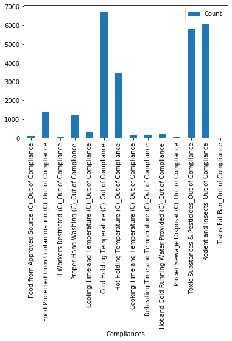

```python
total_violations.plot(kind='bar', x= 'Compliances', y = 'Count')#.show()
```

## Step 3.2

```python
temp_df1=inspection_df.groupby('month_year').size().reset_index()
temp_df1.rename(columns={temp_df1.columns[1]:"count"}, inplace=True)
temp_df2=inspection_df[inspection_df['if_any_violations']==1]
temp_df2=temp_df2.groupby('month_year').size().reset_index()
temp_df2.rename(columns={temp_df2.columns[1]:"count"}, inplace=True)

proportions=[]
proportions=(temp_df2['count']/temp_df1['count']).tolist()
month_year=[]
month_year=temp_df1['month_year'].astype(str).tolist()
```

```
([0,
  1,
  2,
  3,
  4,
  5,
  6,
  7,
  8,
  9,
  10,
  11,
  12,
  13,
  14,
  15,
  16,
  17,
  18,
  19,
  20,
  21,
  22,
  23],
 <a list of 24 Text xticklabel objects>)
```

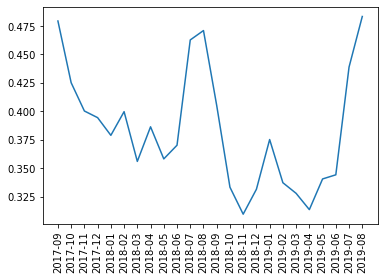

```python
plt.plot(month_year,proportions)
plt.xticks(rotation = 90)
```

Question: Are inspections getting harder or easier over time? Answer: We can clearly see that there is not a trend which would imply if the inspections are getting harder or easier over time.

## Step 3.3

```python
import plotly.graph_objects as go

map_df = inspection_df[inspection_df.Is_Restaurant == 1]
violations = {}
for index, row in map_df.iterrows():
    violations[index] = ''
for index, row in map_df.iterrows():
    temp_str = ''
    for no in range(6,22):
        if row[no] == 1:
            if inspection_df.columns[no] in temp_str:
                continue
            else:
                temp_str = temp_str + inspection_df.columns[no] + ', '
    violations[index] += temp_str

map_df = map_df[['Latitude', 'Longitude', 'if_any_violations']]

temp_dict = {}

for index, row in map_df.iterrows():
    temp_dict[index] = [row[0],row[1],0,'']

for index, row in map_df.iterrows():
    if row[-1] == 1:
        temp_dict[index][2] = 1
        temp_dict[index][3] = violations[index]
map_df = pd.DataFrame(temp_dict).transpose()
#map_df['all_violations'] = violations
map_df = map_df[map_df[1]<0]
map_df_0 = map_df[map_df[2]==0]
map_df_1 = map_df[map_df[2]==1]
#print(map_df)
mapbox_access_token = 'pk.eyJ1IjoibWFsYXYxMjMiLCJhIjoiY2sybzdzYWNnMDl4NTNsbXR3eGszOWJjcSJ9.tBnwk2TQnAuElSMsH24A-A'
class_map_data_1 = go.Scattermapbox(
        lon = map_df_0[1],
        lat = map_df_0[0],
        text = map_df_0[3],
        hoverinfo = 'text',
        mode = 'markers',
        marker = dict(
                    color = 'blue',
                    symbol = 'circle',
                    opacity = 1,
                )
)

class_map_data_2 = go.Scattermapbox(
        lon = map_df_1[1],
        lat = map_df_1[0],
        text = map_df_1[3],
        hoverinfo = 'text',
        mode = 'markers',
        marker = dict(
                    color = 'red',
                    symbol = 'circle',
                    opacity = 1,
                )
)

class_map_layout = go.Layout(
        title = 'Restaurants with violations',
        mapbox=go.layout.Mapbox(
            accesstoken=mapbox_access_token,
            zoom=1,
        )
    )

class_map = go.Figure(data=[class_map_data_1, class_map_data_2], layout=class_map_layout)
class_map.show()
```

[interactive chart not shown]

This map here shows all the considered restaurants and it shows whether they are compliant or not. The blue circles shows the compliant restaurants and the red ones shows the one with violations. On hovering over the red ones, we can see the types of violations by that particular restaurants. In the cluster near Silver Spring, Cold Holding Temperature and Rodent and insects seems to be main issue. Near Bethesda also there seems to be a same trend, although not that common in that area. Near The Colony in Germantown, hot and cold holding temperture is a common violation.

# “I pledge on my honor that I have not given or received any unauthorized

# assistance on this assignment.”